# FPCCII - Lab2.2: Correlacao em estimativas e tempo

José Alberto Souza Paulino

03/05/2022

```r
climas = read_csv(here::here("data/clima_cg_jp-semanal.csv"), col_types = "cTdddddd")
```

## **>> ATIVIDADE: LAB2.2**

```r
climas_temp = climas %>%
  mutate(temp_anterior = lag(tmedia, n = 1))
climas_temp = climas_temp %>%
    mutate(temp_anterior_8 = lag(tmedia, n = 8))
climas_temp = climas_temp %>%
    mutate(temp_anterior_52 = lag(tmedia, n = 52))

glimpse(climas_temp)
```

```
## Rows: 2,748
## Columns: 11
## $ cidade           <chr> "Campina Grande", "Campina Grande", "Campina Grande",~
## $ semana           <dttm> 1992-12-27, 1993-01-03, 1993-01-10, 1993-01-31, 1993~
## $ tmedia           <dbl> 26.13333, 26.11905, 25.76667, 25.74000, 26.31429, 26.~
## $ tmax             <dbl> 30.4, 32.4, 32.2, 32.0, 32.7, 32.7, 32.3, 32.3, 32.1,~
## $ tmin             <dbl> 20.7, 19.3, 19.7, 19.9, 19.6, 20.0, 20.4, 21.2, 19.0,~
## $ chuva            <dbl> 0.0, 0.0, 0.0, 0.4, 0.3, 0.0, 4.9, 0.0, 0.0, 6.1, 0.4~
## $ mes              <dbl> 12, 1, 1, 1, 2, 2, 2, 2, 10, 11, 11, 11, 11, 12, 12, ~
## $ ano              <dbl> 1992, 1993, 1993, 1993, 1993, 1993, 1993, 1993, 1993,~
## $ temp_anterior    <dbl> NA, 26.13333, 26.11905, 25.76667, 25.74000, 26.31429,~
## $ temp_anterior_8  <dbl> NA, NA, NA, NA, NA, NA, NA, NA, 26.13333, 26.11905, 2~
## $ temp_anterior_52 <dbl> NA, NA, NA, NA, NA, NA, NA, NA, NA, NA, NA, NA, NA, N~
```

### Questão 01: descrever a relação entre a temperatura de uma semana e a temperatura da semana passada nas duas cidades.

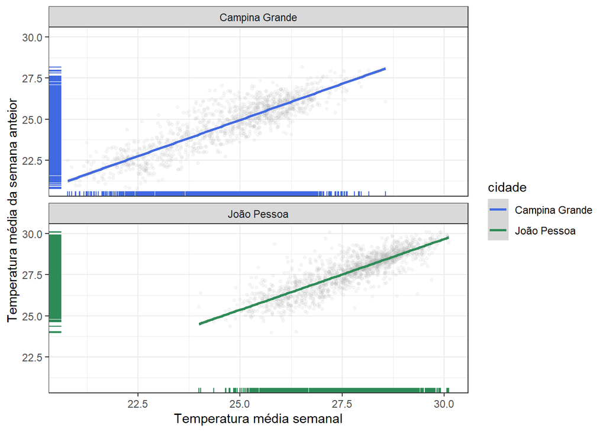

```r
climas_temp %>%
    filter(!is.na(temp_anterior)) %>%
    ggplot(aes(x = tmedia, y = temp_anterior, color = cidade)) +
    facet_wrap(~cidade, nrow = 2) +
    labs(x='Temperatura média semanal', y= "Temperatura média da semana anteior")+
    geom_rug() +
    geom_jitter(size = 1, alpha = 0.1, color = 'darkgray') +
    geom_smooth(formula = y ~ x, method = "lm") +
    scale_color_manual(breaks = c("Campina Grande", "João Pessoa"), values=c("royalblue","seagreen"))
```

Há uma correlação forte, linear e positiva entre as temperaturas de uma semana e a semana antecedente, nas duas cidades. Campina Grande possui uma faixa de valores maior, no entanto, para as duas cidades, observa-se a tendência de que se uma semana n(x) tem uma determinada temperatura média, se espera que a semana subsequente seja tão fria ou quente quanto a semana n(x), ou seja, é incomum grandes variações de temperatura entre as semanas. As impressões sobre essa relação são reforçadas nas tabelas de correlação abaixo, obtidas pelo método de Pearson.

```r
mydata_cg <- climas_temp %>%
    filter(!is.na(temp_anterior)) %>%
    filter(cidade == "Campina Grande") %>%
    select(tmedia, temp_anterior)

mydata_jp <- climas_temp %>%
    filter(!is.na(temp_anterior)) %>%
    filter(cidade == "João Pessoa") %>%
    select(tmedia, temp_anterior)
```

```
## [1] "Correlação entre temperaturas em Campina Grande"
```

```
##                 tmedia temp_anterior
## tmedia        1.000000      0.880168
## temp_anterior 0.880168      1.000000
```

```
## [1] "Correlação entre temperaturas em João Pessoa"
```

```
##                 tmedia temp_anterior
## tmedia        1.000000      0.859407
## temp_anterior 0.859407      1.000000
```

### Questão 02: descrever a relação entre temperatura e chuvas nas semanas em que choveu nas duas cidades.

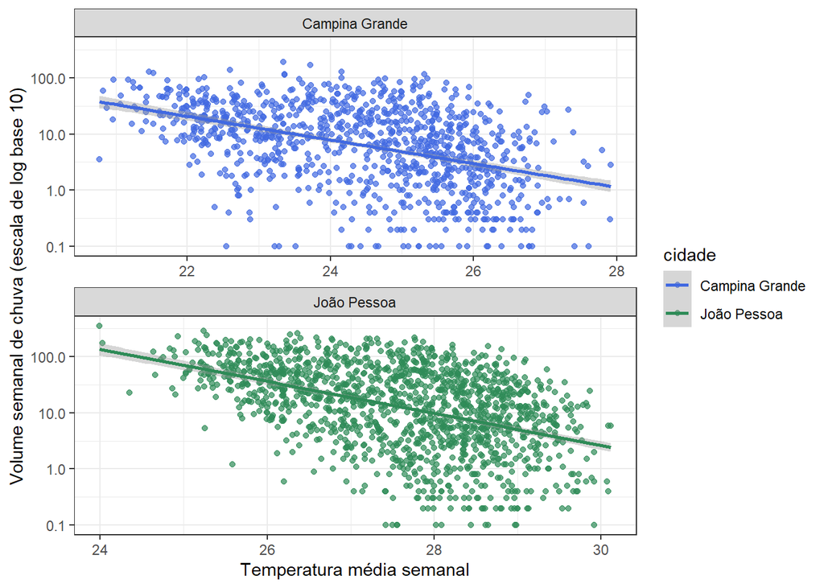

```r
climas_temp %>%
    filter(chuva > 0) %>%
    ggplot(aes(x = tmedia, y = chuva, color = cidade)) +
    #geom_point()+
    facet_wrap(~cidade, nrow = 2, ncol = 1, scales = "free_x") +
    geom_jitter(size = 1.5, alpha = 0.7) +
    geom_smooth(formula = y ~ x, method = "lm")+
    scale_color_manual(breaks = c("Campina Grande", "João Pessoa"), values=c("royalblue","seagreen"))+
    labs(x='Temperatura média semanal', y= "Volume semanal de chuva (escala de log base 10)")+
    scale_y_log10()
```

As visualizações mostram que as relações, nas duas cidades, são linear e negativas. Isso de fato condiz com uma observação empírica, em que há uma tendência de que dias mais chuvosos, normalmente são mais frios. Mas nem sempre é assim, e essa observação é reforçadas porque ambos os gráficos apontam uma correlação fraca, cuja nuvem de pontos está dispersa em quase toda faixa de valores, principalmente me Campina Grande, em que há semanas com pouca chuva tanto em temperaturas baixas como em altas.